# Módulo 5

Métodos no supervisados

Eloy Alvarado Narváez

eloy.alvarado@usm.cl

Universidad Técnica Federico Santa María

Esteban Salgado Valenzuela

Universidad Técnica Federico Santa María

14 de diciembre de 2024

## Aprendizaje no supervisado

### No supervisado vs Supervisado

- Hemos visto modelos supervisados (ej: regresión, clasificación).
- En ese contexto se observan características $X_1,\ldots,X_p$ y una respuesta $Y$ para cada dato.
  - Se busca predecir $Y$ usando $X_1,\ldots,X_p$
- En el aprendizaje no supervisado, solo se observan las características $X_1,\ldots,X_p$.
  - No hay predicción.
- El objetivo es descubrir cosas interesantes de los datos.
  - ¿Se pueden visualizar los datos con sentido?
  - ¿Podemos descubrir subgrupos entre las variables u observaciones?

## Aprendizaje no supervisado

### No supervisado vs Supervisado

- El aprendizaje no supervisado es más subjetivo que el supervisado.
  - No hay un objetivo simple de análisis, como una predicción o respuesta.
- Usualmente, es más fácil obtener datos sin etiqutar que etiqutados.
  - El etiquetado puede requerir intervención humana.

# Análsis de Componentes Principales

## Análsis de Componentes Principales (PCA)

- PCA produce una representación de baja dimensión del conjunto de datos.
- Encuentra una secuencia de combinaciones lineales de las variables con máxima varianza y mutuamente no correlacionadas.
  - Puede producir variables alternativas para usar en problemas de aprendizaje supervisado.
  - También sirve como herramiente para la visualización de datos.

## Análsis de Componentes Principales (PCA)

### Primera Componente Principal

- El primer componente principal de un conjunto de características $X_1,\ldots,X_p$ es la combinación lineal normalizada de las características:
  $$Z_1 = \phi_{11}X_1+\cdots+\phi_{p1}X_p$$
  que maximiza la varianza.
  - Normalizado significa que $\|\phi_1\|^2_2 = 1$, con $\phi_1 = (\phi_{11},\ldots,\phi_{p1})^\top.$
  - ¿Por qué normalizar?

## Análsis de Componentes Principales (PCA)

### Ejemplo

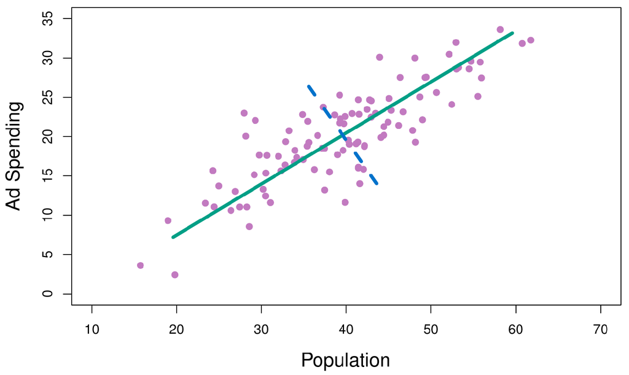

## Análsis de Componentes Principales (PCA)

### Cálculo de Componentes Principales

- Conjunto de datos $X$ de $n\times p$.
  - Se asumen datos centrados (promedio de las columnas es $0$).
  - Simplifica los cálculos.
- Se busca la combinación lineal de las características
  $$z_{i1} = \phi_{11}x_{i1} + \cdots + \phi_{p1}x_{ip}$$
  que maximiza la varianza, sujeto a $\|\phi_1\|^2_2 = 1$.
- Como las columnas de $X$ tienen promedio $0$, también lo tiene $z_{i1}$ (independiente del valor de $\phi_1$).
  - La varianza de $z_{i1}$ puede escribirse $\frac{1}{n}\sum\limits_{i=1}^nz_{i1}^2.$

## Análsis de Componentes Principales (PCA)

### Cálculo de Componentes Principales

- Entonces el problema de encontrar el primer componente principal, consiste en resolver el problema

$$\begin{equation*}
\begin{array}{rrl}
\max\limits_{\phi_1} & \frac{1}{n}\sum\limits_{i=1}^n\left(\sum\limits_{j=1}^p\phi_{j1}x_{ij}\right)^2 &\\
\text{s.t.} & \sum\limits_{j=1}^p\phi_{j1}^2 &= 1
\end{array}
\end{equation*}$$

- Se puede resolver con descomposición de valores singulares (SVD).
- $Z_1$ es el primer componente principal con valores de realización $z_{11},\ldots,z_{n1}$.

## Análsis de Componentes Principales (PCA)

### Geometría de PCA

- El vector de loading $\phi_1$ define una dirección en el espacio de las características donde los datos varían más.
- Si se proyectan los $n$ datos $x_1,\ldots,x_n$ en esta dirección, los valores proyectados son $z_{11},\ldots,z_{n1}$.

## Análsis de Componentes Principales (PCA)

### Más componentes principales

- La segunda componente principal, es la combinación lineal de $X_1,\ldots,X_p$ que tiene máxima varianza entre las combinaciones lineales que no están correlacionadas con $Z_1$.
- Los valores de la segunda componente principal toman la forma
  $$z_{i2} = \phi_{12}x_{i1} + \cdots + \phi_{p2}x_{ip}$$
  - El vector de *loading* asociado es $\phi_2 = (\phi_{12},\ldots,\phi_{p2})^\top$.
- Que $Z_2$ y $Z_1$ no estén correlacionados, es equivalente a $\phi_2\perp\phi_1$.
- Hay, a lo más, $\min(n-1,p)$ componentes principales.

## Análsis de Componentes Principales (PCA)

### Otra interpretación

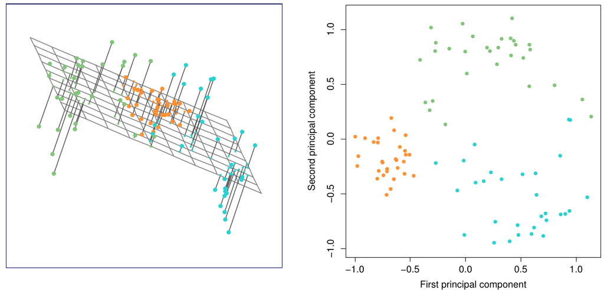

## Análsis de Componentes Principales (PCA)

### Otra interpretación

- PCA encuentra el hiperplano más “cercano” a las observaciones.
- El primer vector *loading* define la línea en un espacio $p$-dimensional más cercana a las $n$ observaciones.
  - usando la distancia euclidiana cuadrada promedio.
- Los primeros dos vectores *loading* definen el plano en $p$-dimensiones más cercano a las $n$ observaciones…

## Análsis de Componentes Principales (PCA)

### Escalar variables

- Si las variables están en diferentes unidades de medida, escalarlas para tener desviación estándar igual a 1 es recomendable.
- Si las variables están en las mismas unidades, se puede decidir escalar o no.

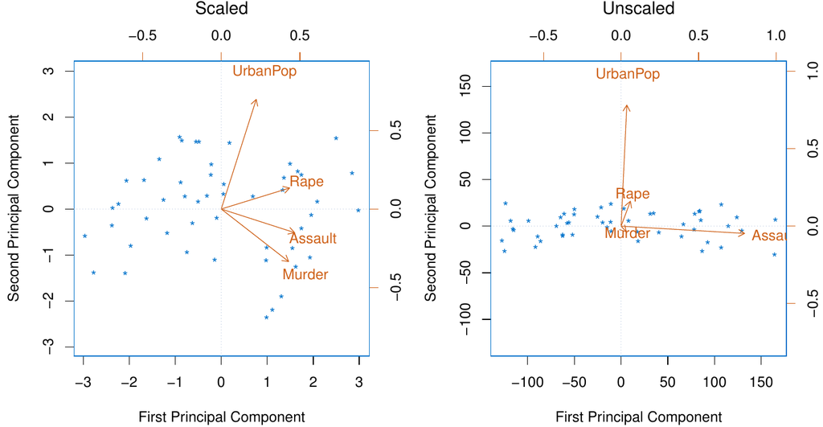

## Análsis de Componentes Principales (PCA)

### Proporción de la Varianza Explicada (PVE)

- Para entender la “fuerza” de cada componente, nos interesa conocer la proporción de la varianza explicada por cada uno.
- La varianza total de un conjunto de datos (con media $0$) es:
  $$\sum\limits_{j=1}^pVar(X_j) = \sum\limits_{j=1}^p\frac{1}{n}\sum\limits_{i=1}^nx_{ij}^2.$$
- La varianza explicada por el $m$-ésimo componente principal es:
  $$Var(Z_m) = \frac{1}{n}\sum\limits_{i=1}^nz_{im}^2.$$

## Análsis de Componentes Principales (PCA)

### Proporción de la Varianza Explicada (PVE)

- Se puede mostrar que:
  $$\sum\limits_{j=1}^pVar(X_j) = \sum\limits_{m=1}^{\min\{n-1,p\}}Var(Z_m)$$
- El PVE del $m$-ésimo componente principal está dado por la cantidad (entre $0$ y $1$)
  $$PVE_{(m)} = \dfrac{\sum\limits_{i=1}^nz_{im}^2}{\sum\limits_{j=1}^p\sum\limits_{i=1}^nx_{ij}^2}$$

## Análsis de Componentes Principales (PCA)

### Proporción de la Varianza Explicada (PVE)

- Los PVE suman 1 $\left(\sum\limits_{m}PVE_{(m)} = 1\right)$.

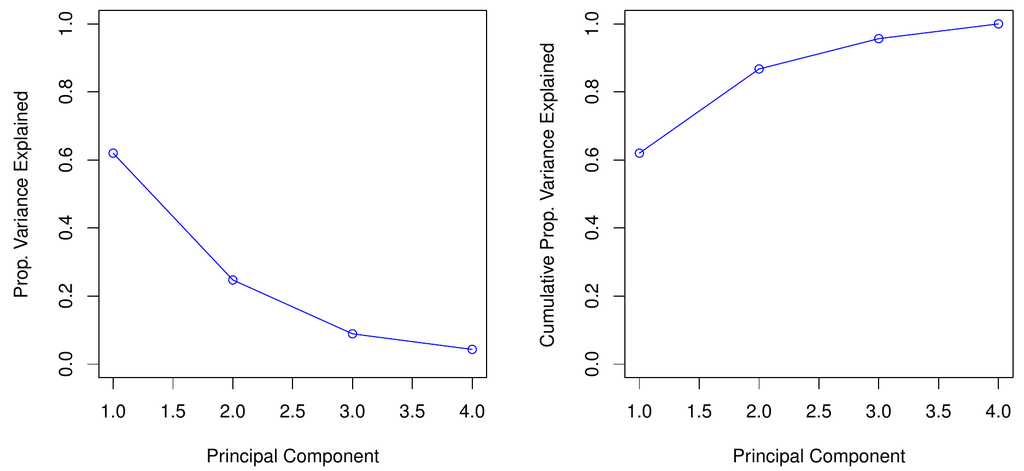

## Análsis de Componentes Principales (PCA)

### ¿Cuántos componentes principales usar?

- No hay una respuesta simple a esta pregunta.
  - No se puede usar *cross-validation*, a menos que sea en un contexto supervisado.
- En la práctica, se busca el “codo”.

# Métodos de Clustering

## Métodos de Clustering

### PCA vs Clustering

- PCA busca una representación de baja dimensión de las observaciones que explique una gran parte de la varianza.
- Clustering busca subgrupos homogéneos en las observaciones.

## Métodos de Clustering

### Ejemplo: Segmentación de mercado

- Supongamos que tenemos acceso a una gran cantidad de medidas de un gran número de personas.
  - Ej: ingreso medio del hogar, ocupación, distancia al área urbana más cercana, etc.
- Se busca segmentar el mercado identificando subgrupos de personas más receptivas.
  - A un tipo de publicidad o afinidad a comprar cierto producto.
- Esto consiste en hacer un clustering de las personas en el conjunto de datos.

## Métodos de Clustering

### Dos tipos de clustering

- $K$-means: Se busca una partición de las observaciones en un número previamente definido de clusters.
- Clustering jerárquico: No se sabe a priori cuántos clusters se quieren.
  - Se obtiene una estructura tipo árbol que permite visualizar los clusters obtenidos para un número de clusters entre $1$ y $n$.

## Métodos de Clustering

### $K$-means

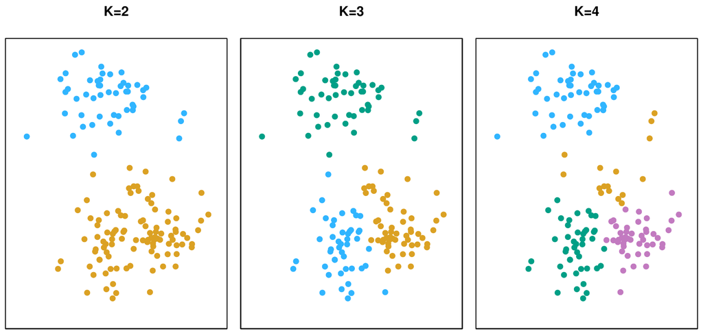

## Métodos de Clustering

### $K$-means

- Se busca particionar el conjunto de observaciones $\{1,\ldots,n\}$ en $K$ conjuntos $C_1,\ldots,C_k$.
  - La unión forma todas las observaciones.
  - Los conjuntos no se traslapan.
- Si la $i$-ésima observación está en el $k$-ésimo cluster se dice que $i∈ C_k$.
- Se busca que la variación inter-cluster sea tan pequeña como sea posible.

## Métodos de Clustering

### $K$-means

- La variación inter-cluster del cluster $C_k$ es una medida $WCV(C_k)$ de la cantidad que las observaciones dentro del cluster difieren entre sí.
  - Se busca resolver
    $$\min\limits_{C_1,\ldots,C_K}\left\{\sum\limits_{k=1}^KWCV(C_k)\right\}$$
- Típicamente se usa la distancia Euclideana:

$$WCV(C_k) = \frac{1}{|C_k|}\sum\limits_{i,i'\in C_k}\sum\limits_{j=1}^p(x_{ij}-x_{i'j})^2$$

## Métodos de Clustering

### $K$-means: Algoritmo

1. Asignar aleatoriamente un número del $1$ a $K$ a cada observación.
- Es una agrupación inicial.
2. Iterar hasta que no haya cambios de asignación:
   1. Calcular el centroide de cada cluster. Vector promedio de los datos del cluster.
   2. Asignar a cada observación el cluster cuyo centroide sea el más cercano (euclideano).

## Métodos de Clustering

### $K$-means: Algoritmo

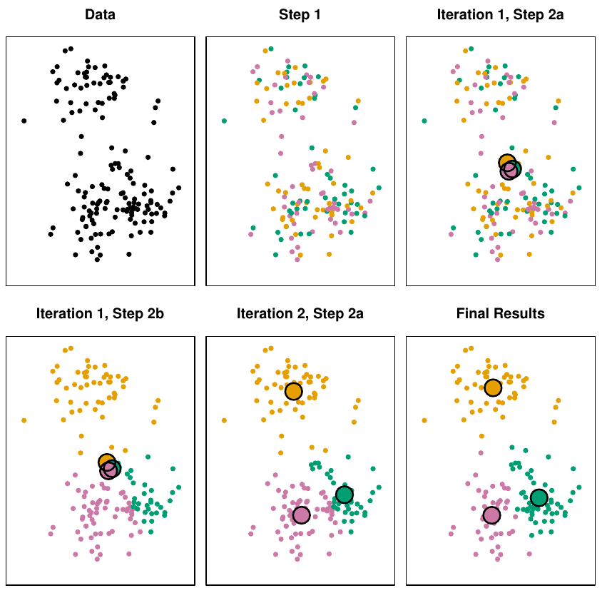

## Métodos de Clustering

### $K$-means: Algoritmo

- El algoritmo hace que el valor objetivo decrezca en cada iteración.
  $$\frac{1}{C_k}\sum\limits_{i,i'∈ C_k}\|x_i-x_{i'}\|^2_2 = 2\sum\limits_{i∈ C_k}\|x_i-\bar{x}_k\|^2_2$$
- No se garantiza obtener el óptimo global.
  - Problema no convexo, óptimo local.

## Métodos de Clustering

### $K$-means: Algoritmo: Punto de partida

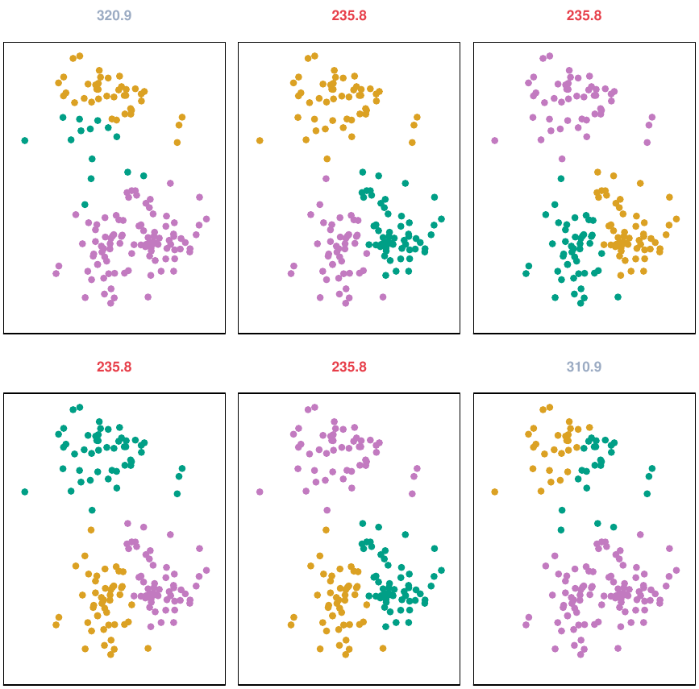

## Métodos de Clustering

### Cluster jerárquico

- $K$-means requiere que el número de clusters sea previamente definido.
- Cluster jerárquico no requiere saber a priori el número de clusters.
  - El tipo más común de cluster jerárquico es el *`bottom-up`* o `aglomerativo`.

## Métodos de Clustering

### Cluster jerárquico

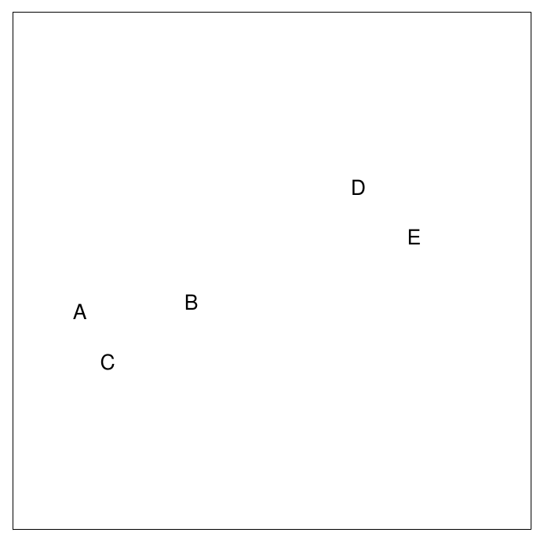

## Métodos de Clustering

### Cluster jerárquico

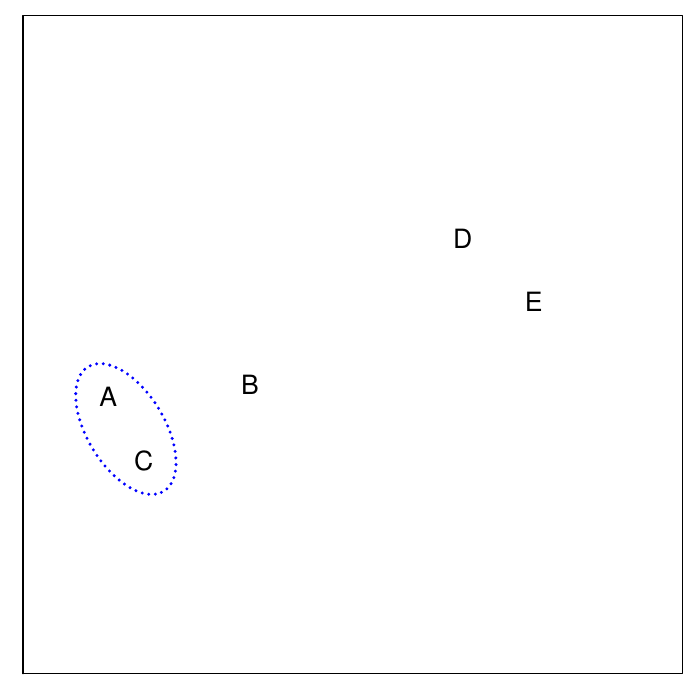

## Métodos de Clustering

### Cluster jerárquico

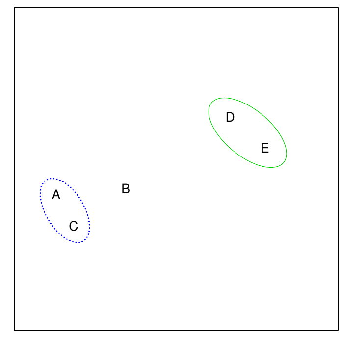

## Métodos de Clustering

### Cluster jerárquico

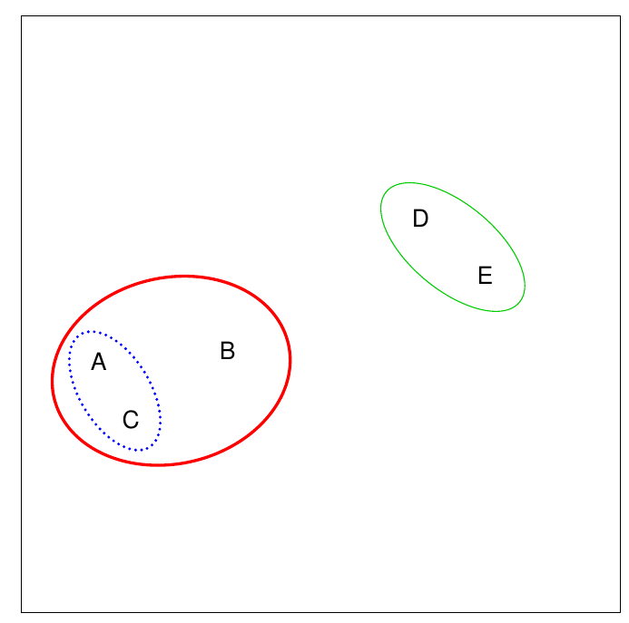

## Métodos de Clustering

### Cluster jerárquico

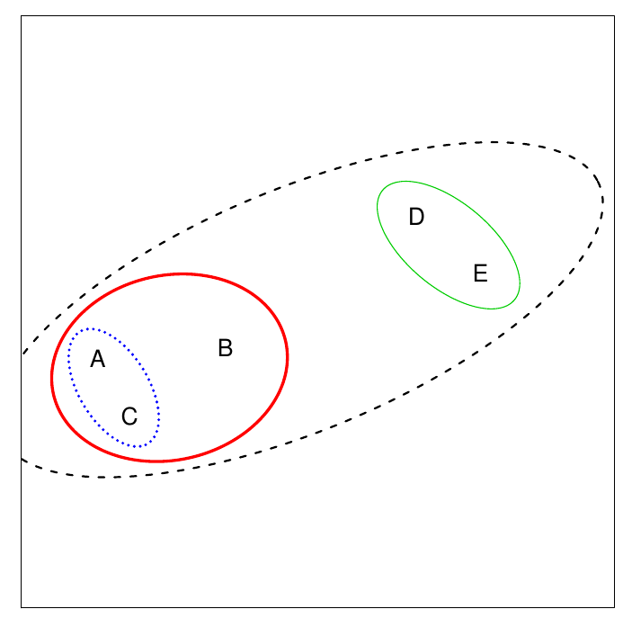

## Métodos de Clustering

### Cluster jerárquico

- Se comienza con cada dato en su propio cluster.
- Se identifican los dos clusters más cercanos y se unen.
- Se repite hasta que todos los puntos estén en un único cluster.

## Métodos de Clustering

### Cluster jerárquico

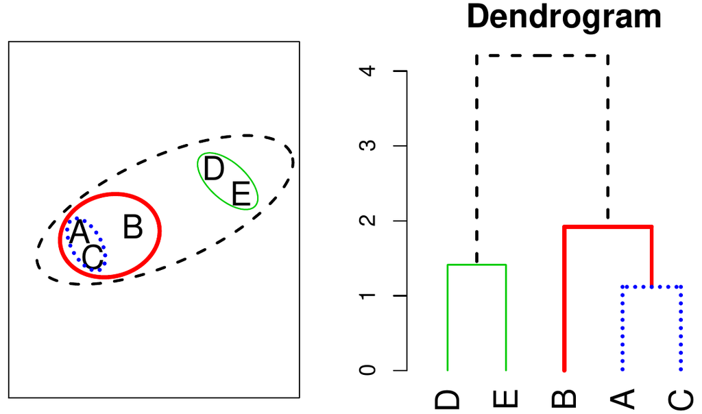

## Métodos de Clustering

### Cluster jerárquico: Ejemplo

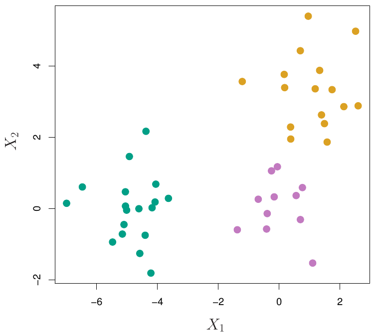

## Métodos de Clustering

### Cluster jerárquico: Ejemplo

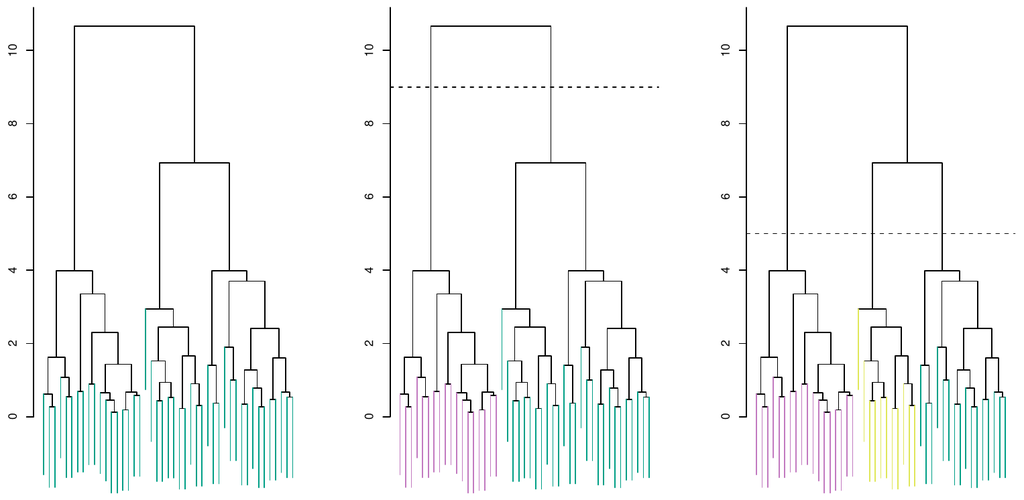

## Métodos de Clustering

### Cluster jerárquico: Tipos de unión

- `Complete:` Disimilitud máxima inter cluster.
- `Single:` Disimilitud mínima inter cluster.
- `Average:` Disimilitud promedio inter cluster.
- `Centroid:` Disimilitud de centroides inter cluster.

## Métodos de Clustering

### Cluster jerárquico: Tipos de unión

- Usualmente, se calcula la disimilitud en función de la distancia Euclideana.
- Otra opción es la distancia basada en correlación
  - Correlación en los perfiles de observación.

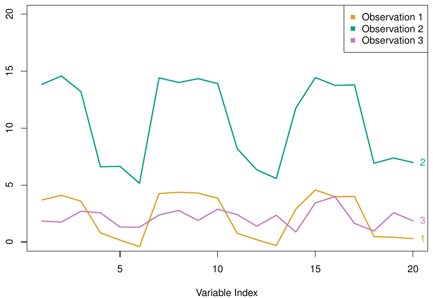

## Métodos de Clustering

### En la práctica

- Las escalas importan.
  - Estandarizar (promedio $0$, varianza $1$).
- ¿Cuántos clusters?
  - No hay una respuesta consensuada.
- ¿Qué características usar formar los clusters?